# R <-

#### Índice

- Uso básico da linguagem
- Variáveis
- Vetores
- Operaçẽos com vetores
- Matrizes
- Operações com matrizes
- Funções internas
- Funções internas para aritmética em geral
- Aplicação em estatística
- Desvio Padrão
- Regressão Linear
- Graficos
- Scatter
- Boxplot
- Histograma
- Pacotes essenciais
- Dplyr
- Select
- Filter
- Arrange
- Mutate
- Pipes

### Uso básico da linguagem

#### Atrubuição de variáveis

```r
n <- ((5 + 5) * 4) / 2
n
```

```
[1] 20
```

```r
sqrt(n + 5) -> sq
sq
```

```
[1] 5
```

```r
sq ^ 3
```

```
[1] 125
```

### Vetores

```r
v <- c(1,2,3,4,5)
v
```

```
[1] 1 2 3 4 5
```

```r
v <- 1:5
v
```

```
[1] 1 2 3 4 5
```

```r
seq(5) -> v
v
```

```
[1] 1 2 3 4 5
```

```r
v <- seq.int(from = 1, to = 5, by = 1)
v
```

```
[1] 1 2 3 4 5
```

Vetores podem ter seus índices nomeados:

```r
v_names <- c("um", "dois", "três", "quatro", "cinco")
names(v) <- v_names
v
```

```
    um   dois   três quatro  cinco
     1      2      3      4      5
```

#### Operações com vetores

Em uma operação entre um vetor e um escalar todos os índices sofrem a operação:

```r
v * n
```

```
    um   dois   três quatro  cinco
    20     40     60     80    100
```

```r
v ** 2
```

```
    um   dois   três quatro  cinco
     1      4      9     16     25
```

É possível operar índices específicos:

```r
vis <- v[1] + v[3]
vis
```

```
um
 4
```

Qunado a operação é feita entre dois vetores do mesmo tamanho todos os indices são operados pelos indices do outro vetor:

```r
v2 <- c(2,2,2,2,2)
v +v2
```

```
    um   dois   três quatro  cinco
     3      4      5      6      7
```

Se os tamanhos forem diferentes a operação é realizada com um aviso. Os valores do vetor menor são repetidos na operação:

```r
v2 <- c(3,3,3)
v * v2
```

```
longer object length is not a multiple of shorter object length
```

```
    um   dois   três quatro  cinco
     3      6      9     12     15
```

### Filtragem

Vetores podem ser filtrados por range

```r
v[1:3]
```

```
  um dois três
   1    2    3
```

Também podem ser filtrados através de condicionais. O caso abaixo retorna um vetor de boleanos que satisfaça a condição:

```r
v > 3
```

```
    um   dois   três quatro  cinco
 FALSE  FALSE  FALSE   TRUE   TRUE
```

Para retornar os valores este vetor de boleanos deve ir dentro da indexação:

```r
v[v>3]
```

```
quatro  cinco
     4      5
```

### Matrizes

Matrizes só podem ter um tipo de valor. Inicialização:

```r
m1 <- matrix(1:20, nrow = 4, ncol = 5)
m1
```

```
     [,1] [,2] [,3] [,4] [,5]
[1,]    1    5    9   13   17
[2,]    2    6   10   14   18
[3,]    3    7   11   15   19
[4,]    4    8   12   16   20
```

#### Operações com matrizes

A lógica para operações com escalares é a mesma para vetores:

```r
m1 * 5
```

```
     [,1] [,2] [,3] [,4] [,5]
[1,]    5   25   45   65   85
[2,]   10   30   50   70   90
[3,]   15   35   55   75   95
[4,]   20   40   60   80  100
```

Em operações com vetores e matrizes cada coluna da matriz é percorrida pelo vetor em ordem e depois se repete:

```r
m1 * v
```

```
     [,1] [,2] [,3] [,4] [,5]
[1,]    1   25   36   39   34
[2,]    4    6   50   56   54
[3,]    9   14   11   75   76
[4,]   16   24   24   16  100
```

Os valores de duas matrize podem ser operados se elas possuirem a mesma quantidade de linhas e colunas:

```r
m2 <- matrix(20:39, nrow = 4, ncol = 5)
m1 * m2
```

```
     [,1] [,2] [,3] [,4] [,5]
[1,]   20  120  252  416  612
[2,]   42  150  290  462  666
[3,]   66  182  330  510  722
[4,]   92  216  372  560  780
```

```r
m1 + m2
```

```
     [,1] [,2] [,3] [,4] [,5]
[1,]   21   29   37   45   53
[2,]   23   31   39   47   55
[3,]   25   33   41   49   57
[4,]   27   35   43   51   59
```

Para de fato multiplcar duas matrizes a regra matemática precisa se respeitada (l1 = c2). O operador correto é %*%

```r
m3 <- matrix(1:20, nrow = 5, ncol = 4)
m1 %*% m3
```

```
     [,1] [,2] [,3] [,4]
[1,]  175  400  625  850
[2,]  190  440  690  940
[3,]  205  480  755 1030
[4,]  220  520  820 1120
```

### Funções Internas

#### Funções para aritimética em geral

#### Soma (sum).

Soma todos os valores de um vetor

```r
random_vec <- sample(30)
random_vec
```

```
 [1]  2 26 29 18 22  3  1 25 10 28 30 19 13 17 20  4 15  9 21 23 16  7 14  8  6 12  5 27 24 11
```

```r
sum(random_vec)
```

```
[1] 465
```

Também pode ser utilizado junto com filtragem, para contar a quantidade de ocorrencias dada uma determinada condição:

```r
sum(mtcars$gear == 4)
```

```
[1] 12
```

Neste caso o resultado indicad que a tabela “mtcars” possui 12 ocorrencias cuja coluna gear é igaual a 4, ou seja, 12 carros de 4 marchas

#### Média Aritimética símples

## $\bar{x} = \frac{\sum_{i=1}^n x_{i}}{n}$

```r
vec_m <- c(1,2,3,4,5,6,7,8,9,10,30)
mean(vec_m)
```

```
[1] 7.727273
```

#### Mediana

```r
median(vec_m)
```

```
[1] 6
```

### Aplicação em estatística

## $\sigma = \sqrt{\frac{\sum_{i=1(xi_{i} - \bar{x})^2}^{n}}{n}}$

```r
vec_var <- sample(20)
vec_var
```

```
 [1]  6  1 11 16  3  5  7  8 17 10  2 14 19 15  4 20 12 18  9 13
```

```r
sd(vec_var)
```

```
[1] 5.91608
```

### Regressão Lianear

Exemplo: Teste da relação entre peso e altura em mulheres:

```r
women
```

| height | weight |
| --- | --- |
| 58 | 115 |
| 59 | 117 |
| 60 | 120 |
| 61 | 123 |
| 62 | 126 |
| 63 | 129 |
| 64 | 132 |
| 65 | 135 |
| 66 | 139 |
| 67 | 142 |

[output cut: 5 more lines]

```r
regWomen <- lm(women$height ~ women$weight)
summary(regWomen)
```

```
Call:
lm(formula = women$height ~ women$weight)

Residuals:
     Min       1Q   Median       3Q      Max
-0.83233 -0.26249  0.08314  0.34353  0.49790

Coefficients:
              Estimate Std. Error t value Pr(>|t|)
(Intercept)  25.723456   1.043746   24.64 2.68e-12 ***
women$weight  0.287249   0.007588   37.85 1.09e-14 ***
---
Signif. codes:  0 ‘***’ 0.001 ‘**’ 0.01 ‘*’ 0.05 ‘.’ 0.1 ‘ ’ 1

Residual standard error: 0.44 on 13 degrees of freedom
Multiple R-squared:  0.991, Adjusted R-squared:  0.9903
F-statistic:  1433 on 1 and 13 DF,  p-value: 1.091e-14
```

## Gráficos

### Scatter

Cada valor é representado por um ponto no eixo cartesiano

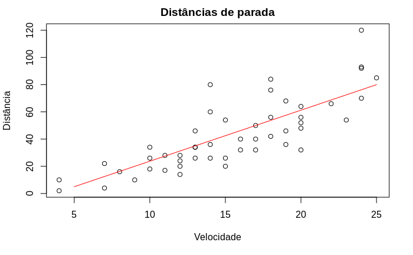

```r
plot(x = cars$speed, y = cars$dist, main = "Distâncias de parada", xlab = "Velocidade", ylab = "Distância")
#Também é possível interferir no gráfico que foi plotado. Os dois comandos devem ser executados juntos.
lines (c(5,25),c(5,80), col='red')
```

### Boxplot

Representa graficamente os valores do mínimo, 1,2 e 3 quartil, mediana e máximo.

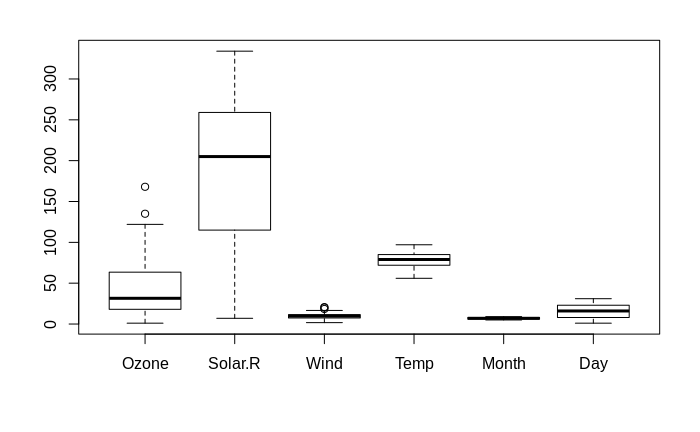

```r
boxplot(airquality)
```

### Histograma

Histograma das frequencias de um dataset

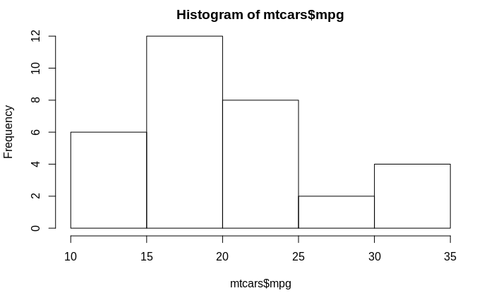

```r
hist(mtcars$mpg)
```

### Dplyr

#### Select

Retorna um subset com a sleção de colunas filtradas

```r
select(mtcars, mpg,hp,qsec,gear)
```

|  | mpg | hp | qsec | gear |
| --- | --- | --- | --- | --- |
| Mazda RX4 | 21.0 | 110 | 16.46 | 4 |
| Mazda RX4 Wag | 21.0 | 110 | 17.02 | 4 |
| Datsun 710 | 22.8 | 93 | 18.61 | 4 |
| Hornet 4 Drive | 21.4 | 110 | 19.44 | 3 |
| Hornet Sportabout | 18.7 | 175 | 17.02 | 3 |
| Valiant | 18.1 | 105 | 20.22 | 3 |
| Duster 360 | 14.3 | 245 | 15.84 | 3 |
| Merc 240D | 24.4 | 62 | 20.00 | 4 |
| Merc 230 | 22.8 | 95 | 22.90 | 4 |
| Merc 280 | 19.2 | 123 | 18.30 | 4 |

[output cut: 22 more lines]

Também pode ser usado com ranges:

```r
select(mtcars, hp:gear)
```

|  | hp | drat | wt | qsec | vs | am | gear |
| --- | --- | --- | --- | --- | --- | --- | --- |
| Mazda RX4 | 110 | 3.90 | 2.620 | 16.46 | 0 | 1 | 4 |
| Mazda RX4 Wag | 110 | 3.90 | 2.875 | 17.02 | 0 | 1 | 4 |
| Datsun 710 | 93 | 3.85 | 2.320 | 18.61 | 1 | 1 | 4 |
| Hornet 4 Drive | 110 | 3.08 | 3.215 | 19.44 | 1 | 0 | 3 |
| Hornet Sportabout | 175 | 3.15 | 3.440 | 17.02 | 0 | 0 | 3 |
| Valiant | 105 | 2.76 | 3.460 | 20.22 | 1 | 0 | 3 |
| Duster 360 | 245 | 3.21 | 3.570 | 15.84 | 0 | 0 | 3 |
| Merc 240D | 62 | 3.69 | 3.190 | 20.00 | 1 | 0 | 4 |
| Merc 230 | 95 | 3.92 | 3.150 | 22.90 | 1 | 0 | 4 |
| Merc 280 | 123 | 3.92 | 3.440 | 18.30 | 1 | 0 | 4 |

[output cut: 22 more lines]

#### Filter

Filtra linhas de acordo com condições. Operadores binários podem ser utilizados

```r
filter(mtcars, hp > 100, wt < 3.000 | qsec > 20.1)
```

| mpg | cyl | disp | hp | drat | wt | qsec | vs | am | gear | carb |
| --- | --- | --- | --- | --- | --- | --- | --- | --- | --- | --- |
| 21.0 | 6 | 160.0 | 110 | 3.90 | 2.620 | 16.46 | 0 | 1 | 4 | 4 |
| 21.0 | 6 | 160.0 | 110 | 3.90 | 2.875 | 17.02 | 0 | 1 | 4 | 4 |
| 18.1 | 6 | 225.0 | 105 | 2.76 | 3.460 | 20.22 | 1 | 0 | 3 | 1 |
| 30.4 | 4 | 95.1 | 113 | 3.77 | 1.513 | 16.90 | 1 | 1 | 5 | 2 |
| 19.7 | 6 | 145.0 | 175 | 3.62 | 2.770 | 15.50 | 0 | 1 | 5 | 6 |
| 21.4 | 4 | 121.0 | 109 | 4.11 | 2.780 | 18.60 | 1 | 1 | 4 | 2 |

#### Arrange

Ordena a tabela de acordo com as variáveis fornecidas. No caso abaixo o primeiro critério de ordenação é a quantidade de cilindros crescente e o segundo é a quantidade de marchas decrescente.

```r
arrange(mtcars, cyl, desc(gear))
```

| mpg | cyl | disp | hp | drat | wt | qsec | vs | am | gear | carb |
| --- | --- | --- | --- | --- | --- | --- | --- | --- | --- | --- |
| 26.0 | 4 | 120.3 | 91 | 4.43 | 2.140 | 16.70 | 0 | 1 | 5 | 2 |
| 30.4 | 4 | 95.1 | 113 | 3.77 | 1.513 | 16.90 | 1 | 1 | 5 | 2 |
| 22.8 | 4 | 108.0 | 93 | 3.85 | 2.320 | 18.61 | 1 | 1 | 4 | 1 |
| 24.4 | 4 | 146.7 | 62 | 3.69 | 3.190 | 20.00 | 1 | 0 | 4 | 2 |
| 22.8 | 4 | 140.8 | 95 | 3.92 | 3.150 | 22.90 | 1 | 0 | 4 | 2 |
| 32.4 | 4 | 78.7 | 66 | 4.08 | 2.200 | 19.47 | 1 | 1 | 4 | 1 |
| 30.4 | 4 | 75.7 | 52 | 4.93 | 1.615 | 18.52 | 1 | 1 | 4 | 2 |
| 33.9 | 4 | 71.1 | 65 | 4.22 | 1.835 | 19.90 | 1 | 1 | 4 | 1 |
| 27.3 | 4 | 79.0 | 66 | 4.08 | 1.935 | 18.90 | 1 | 1 | 4 | 1 |
| 21.4 | 4 | 121.0 | 109 | 4.11 | 2.780 | 18.60 | 1 | 1 | 4 | 2 |

[output cut: 22 more lines]

#### Mutate

Insere novas variáveis na tabela. É possível utilizar outras variáveis como base para os valores

```r
mutate(USArrests, murder_prop = Murder / (Assault + Rape))
```

| Murder | Assault | UrbanPop | Rape | murder_prop |
| --- | --- | --- | --- | --- |
| 13.2 | 236 | 58 | 21.2 | 0.05132193 |
| 10.0 | 263 | 48 | 44.5 | 0.03252033 |
| 8.1 | 294 | 80 | 31.0 | 0.02492308 |
| 8.8 | 190 | 50 | 19.5 | 0.04200477 |
| 9.0 | 276 | 91 | 40.6 | 0.02842704 |
| 7.9 | 204 | 78 | 38.7 | 0.03255047 |
| 3.3 | 110 | 77 | 11.1 | 0.02725021 |
| 5.9 | 238 | 72 | 15.8 | 0.02324665 |
| 15.4 | 335 | 80 | 31.9 | 0.04197329 |
| 17.4 | 211 | 60 | 25.8 | 0.07347973 |

[output cut: 40 more lines]

#### Pipes

É possível encadear todas estas funções com um pipe ( %>% ):

```r
airquality %>% filter(Month == 8) %>% select(Ozone,Temp,Wind) %>% mutate(vento_ao_quadrado = Wind ** 2)
```

| Ozone | Temp | Wind | vento_ao_quadrado |
| --- | --- | --- | --- |
| 39 | 81 | 6.9 | 47.61 |
| 9 | 81 | 13.8 | 190.44 |
| 16 | 82 | 7.4 | 54.76 |
| 78 | 86 | 6.9 | 47.61 |
| 35 | 85 | 7.4 | 54.76 |
| 66 | 87 | 4.6 | 21.16 |
| 122 | 89 | 4.0 | 16.00 |
| 89 | 90 | 10.3 | 106.09 |
| 110 | 90 | 8.0 | 64.00 |
| NA | 92 | 8.6 | 73.96 |

[output cut: 21 more lines]